# Lecture 10：個人別需要からターゲティングへ

計量経済学II

Kei Ikegami

## 第9回から今回へ

- 同じ人の選択履歴から、価格感応度の事後分布を得た。
- 今回は、その分布を使ってクーポンの配り方を選ぶ。
- 購買確率だけでなく、値引きで失うマージンも考える。

Quiz 10：少ない履歴、既存/新規、事後予測を復習。

## よく買う人に配ればよいか

通常のマージン300円、クーポン100円。

| 顧客 | 通常の確率 | クーポンあり | 通常利益 | 施策利益 | 増分 |
| --- | --- | --- | --- | --- | --- |
| A | .90 | .95 | 270円 | 190円 | −80円 |
| B | .30 | .60 | 90円 | 120円 | +30円 |

購入を予測することと、施策で増える利益を予測することは違う。

## 施策の範囲を決める

- 企業はイヤホンAだけを販売する。
- Aは12千円、原価1千円。競合Bは12千円で固定。
- 値引き候補は0・1・2・3千円。配信費用は0。
- 1回の購買機会。競合の価格反応や在庫制約は扱わない。

「何もしない」も選択肢に含める。

## 個人の需要

$$q_i(c;\theta_i)=\frac{e^{x_A'\beta-e^{\theta_i}(p_A-c)}}
{1+e^{x_A'\beta-e^{\theta_i}(p_A-c)}+e^{x_B'\beta-e^{\theta_i}p_B}}.$$

第9回と同じ $\alpha_i=e^{\theta_i}$。属性係数は教育上の簡略化として既知。

## 事後分布で平均する

$$\bar q_i(c)\approx\frac1B\sum_b q_i(c;\theta_i^{(b)}).$$

係数を平均してからlogitへ代入するのとは違う。

$$\bar\pi_i(c)=(p_A-c-m)\bar q_i(c)-k(c).$$

配信費 $k(c)$ があれば購入しなかった人の分も差し引く。

## 個別と一律

$$c_i^*=\arg\max_c\bar\pi_i(c),\qquad
c^{uniform}=\arg\max_c\sum_i\bar\pi_i(c).$$

どちらも同じ期待利益の基準。 全員に同じクーポンを配る制約があるかどうかが違う。

## 価格はどう割り当てられたか

- 今回は提示価格と属性を無作為に割り当てた。
- 実際の購買履歴では、価格の内生性を検討する。
- 階層ベイズに変えても、割当の問題は解消しない。
- CBCの仮想回答から実購買に使うには、外的妥当性の確認が必要。

以下は両者に同じモデルが成り立つという教育用の仮定を置く。

## 第9回の推定を再現

300人、学習8問＋holdout8問。

| parameter | truth | posterior_mean | lower | upper | split_Rhat |
| --- | --- | --- | --- | --- | --- |
| mu | -2.3 | -2.333 | -2.448 | -2.228 | 1.003 |
| tau | 0.6 | 0.611 | 0.506 | 0.728 | 1.007 |

真値は検算専用。施策選びには使わない。

## 個人差と不確実性

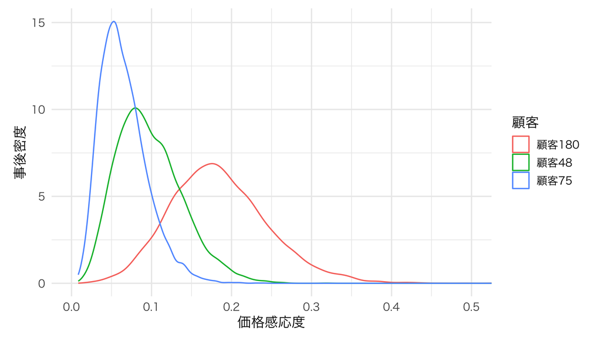

分布の重なりを残したまま予測する。

## 同じ値引きでも反応が違う

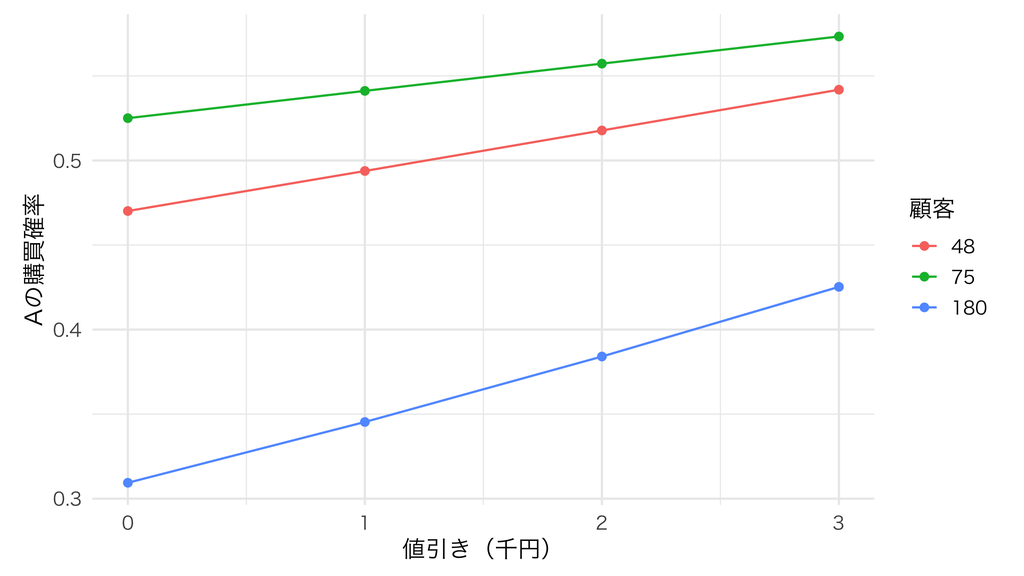

## 増分利益を比べる

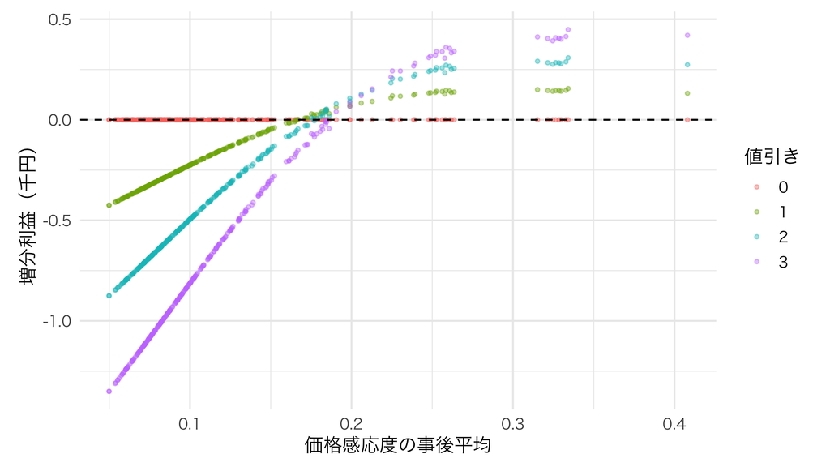

元々買う人への値引きも含む。

## 一律と個人別の比較

| policy | posterior | truth |
| --- | --- | --- |
| 配布なし | 4.8090 | 4.7474 |
| 全員に3千円 | 4.1048 | 4.0781 |
| 最適な一律 | 4.8090 | 4.7474 |
| 個人別 | 4.8400 | 4.7792 |

事後期待利益では個人別が一律以上になる。 実際の利益で必ず上回るという保証ではない。

## 利益差の不確実性

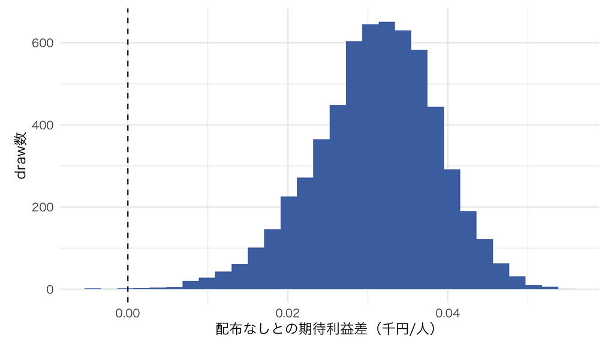

ルールを固定して各drawで評価する。 各drawで別の最適ルールを選び直さない。

## モデルで候補を選び、実験で確かめる

1. 履歴で需要を推定し、配布ルールを決める。
2. ルールを固定する。
3. 新しい購買機会で「ルール適用/配布なし」を無作為に割り当てる。
4. 実現利益を比較する。

クーポンを使った人だけの比較にしない。

## 新しいランダム化実験

| estimate | lower | upper | truth |
| --- | --- | --- | --- |
| -0.187 | -1.438 | 1.063 | 0.032 |

小さい利益改善を検出するには、十分な人数が必要。 同じ顧客の繰り返し観測では標準誤差もその依存を考慮する。

## 購入予測とCATE

$$E[Y_i(0)\mid X_i=x]\quad\text{と}\quad
\tau(x)=E[Y_i(1)-Y_i(0)\mid X_i=x].$$

- 左：何もしなくても買うか。
- 右：指定した施策でどれくらい変わるか。
- 価格感応度 $\alpha_i$ 自体がCATEではない。

## 実証研究

- Rossi et al. (1996)：購買履歴を使うクーポン。モデル上の純収益増が一律の2.5倍。
- Dubé & Misra (2023)：無作為価格実験から個別価格へ。最適な一律より事後期待利益19%増。
- Ascarza (2018)：2つの実験。離脱リスクと施策反応を区別する。

数値の比較対象と出典は講義ノート参照。

## まとめ

- 事後分布から施策ごとの購買確率を計算する。
- 値引き後の利益を比べて施策を選ぶ。
- 価格の割当と仮想回答の外的妥当性を確認する。
- 選んだルールを別のランダム化実験で評価する。

Playground 10 / 課題10

## 次回：長期価値へ

今日は1回の購買機会を考えた。 次回は、その先に何回買ってくれそうかを購買履歴から予測する。

CLVが高いことと、施策で価値が増えることは引き続き区別する。